# act_report

## Report: act_report

To answer some important questions about dogs, we gathered assessed and cleaned a dogs rating data set gathered from the archive of official WeRateDogs Twitter account from year 2015 to year 2017, we have investegated some insights and did some usefull visualizations to answer the following questions:

- Using this data set Which dogs or what are the Top dog types that has most high average favorite count:

  To answer this question we should first group the data set by the dog type and order them by the average favorite count then we take only the top results, so we got:
  1. No 1: Dog Type Whippet: with average favorite count greater than 23000
  2. No 2: Dog Type Persian cat: with average favorite count almost equal to Whippet's average favorite count (between 22000 and 23000
  3. No 3: Dog Type Grey fox: with average favorite count almost equal 22000
  4. No 4: Dog Type Bedlington terrier: with average favorite count almost equal 21000
  5. No 5: Dog Type Saluki: with average favorite count equal to 20000

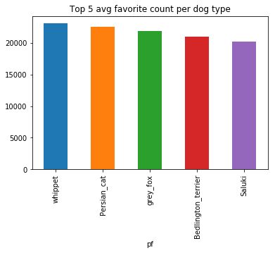

- Is it possible to determine the relation between favorite count and retweet count:

  The answer is yes, and useing this data set we have we got a prety obvious relation between favorite count and retweet count.

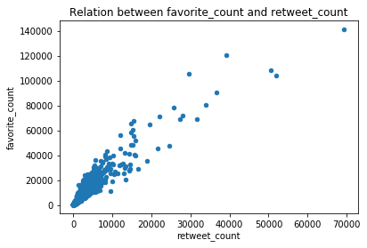

We obviously can see that there is a relation between favorite count and retweet, it's a positive relation (whenever the favorite count increases the retweet count increases , the reverse is true) and this one does make sense , because when the retweet count increases for sure the reach of tweet will increase too ,and with reach increasing the favorite count increases too

- Is it possible to determine the relation between favorite count and dog rating:

  Using this data set we can determine this one

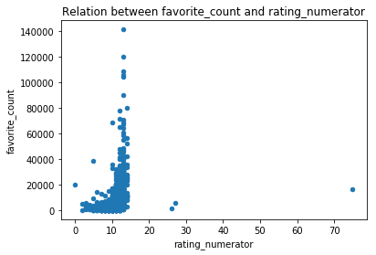